# TMDB box office prediction- Modeling(Xgboost, Neural Network, SVM, RandomForest )

Mianchun Lu, Yuting Gong, Cijun Sun, Guangxu Luo

## PART II Modeling

```r
library(rJava)
library(qdap)
library(gtools)
library(tidytext)
library(tm)
library(stringr)
library(syuzhet)
library(dplyr)
library(gridExtra)
library(wordcloud)
library(xgboost)
library(readr)
library(stringr)
library(caret)
library(car)
library(rsample)      # data splitting
library(gbm)          # basic implementation
library(pdp)          # model visualization
library(ggplot2)      # model visualization
library(lime)         # model visualization
library(tidyr)
library(plyr)
library(randomForest)
library(cluster)
library(flexclust)
library(e1071)
library(MASS)
library(nnet)
```

Read in the cleaned data sets:

```r
train=read.csv("train_clean.csv", stringsAsFactors = FALSE, na.strings = c("","#N/A","[]"))
test=read.csv("test_clean.csv", stringsAsFactors = FALSE,na.strings = c("","#N/A","[]"))
train_cluster = read.csv("train_clean2.csv")
test_cluster = read.csv("test_clean2.csv")
```

```r
train=read.csv("train_clean2.csv", stringsAsFactors = FALSE)
test=read.csv("test_clean2.csv", stringsAsFactors = FALSE)
```

## Xgb model

I choose boosting model, to be more specific, XGboost for several reasons. The xgboost R package provides an R API to “Extreme Gradient Boosting”, which is an efficient implementation of gradient boosting framework.

1. Internally, XGBoost will automatically learn what is the best direction to go when a value is missing. Equivalently, this can be viewed as automatically “learn” what is the best imputation value for missing values based on reduction on training loss.
2. **xgb.cv** function incorporates cross-validation
3. When tuning the parameters, if we include early_stopping_rounds = 10 in the model, it could be re-run if there is no improvement for 10 consecutive trees.

In the following part, I will use xgb model to train the data. There are several variables that I considered irrelavent, so I drop them from the dataset.

```r
drop_var3=c("X","id","original_title","overview","tagline","title","Keywords","revenue", "release_date","budget","budget2","popularity2","runtime2","numberOfGenres2","numberOfcasts2","numberOfcrews2","numberOfcompanies2","numberOflang2","numberOfcoun2","revenue2")
train_xgb=train
test_xgb=test
train_xgb[,drop_var3]<-list(NULL)
test_xgb[,drop_var3]<-list(NULL)
```

In order to fit the xgb model, I need to fix some data to factor firstly, and then convert them to numeric:

```r
train_xgb$original_language=as.numeric(factor(train_xgb$original_language))
train_xgb$month=as.numeric(factor(train_xgb$month))
train_xgb$year = as.numeric(factor(train_xgb$year))
train_xgb$week_day = as.numeric(factor(train_xgb$week_day))

test_xgb$original_language=as.numeric(factor(test_xgb$original_language))
test_xgb$month=as.numeric(factor(test_xgb$month))
test_xgb$year = as.numeric(factor(test_xgb$year))
test_xgb$week_day = as.numeric(factor(test_xgb$week_day))
```

Split the train data and start to train models.

```r
set.seed(617)
split = sample(1:nrow(train_xgb),size = 0.7*nrow(train_xgb))
train_model = train_xgb[split,]
test_model = train_xgb[-split,]
```

```r
# In this model, it only has p1, n1, and frequent words. Afinn has not beed used.
# fit the model with the arbitrary parameters
train_model0=train_model
train_model0["log.revenue"]=NULL
test_model0=test_model
test_model0["log.revenue"]=NULL
test_xgb["id"]=NULL

set.seed(123)
# parameter list
params = list(
  eta = 0.01,
  max_depth = 5,
  min_child_weight = 7,
  colsample_bytree = 1)

xgb.fit.final = xgboost(
  params = params,
  data = as.matrix(train_model0),
  label = train_model$log.revenue,
  nrounds = 2000,
  subsample=0.55,
  objective = "reg:linear")
# train-rmse: 0.970085

# for prediction
xgb_scoring=as.matrix(test_model0)
pred1= predict(xgb.fit.final,newdata=xgb_scoring)

rmsle1 <- sqrt(sum((pred1 - log((exp(test_model$log.revenue)-1) + 1))^2)/nrow(test_model))
rmsle1
# 1.908932

xgb_real_test=as.matrix(test_xgb)
pred1.test= predict(xgb.fit.final,newdata=xgb_real_test)
pred1.test_nolog=exp(pred1.test)-1



#kaggle score: 2.25069
```

```r
# grid search
train_xgb0=train_xgb
train_xgb0["log.revenue"]=NULL

hyper_grid <- expand.grid(
  eta = c(.001, .01, .05, .1),
  max_depth = c(3, 5, 7, 9),
  min_child_weight = c(3, 5, 7, 9),
  subsample = c(0.55, .65, .8),
  colsample_bytree = c(.8, .9, 1),
  optimal_trees = 0,               # a place to dump results
  min_RMSE = 0                     # a place to dump results
  )
#
nrow(hyper_grid)

# grid search
for(i in 1:nrow(hyper_grid)) {

  # create parameter list
  params <- list(
    eta = hyper_grid$eta[i],
    max_depth = hyper_grid$max_depth[i],
    min_child_weight = hyper_grid$min_child_weight[i],
    subsample = hyper_grid$subsample[i],
    colsample_bytree = hyper_grid$colsample_bytree[i]
  )# reproducibility

  # train model
  xgb.tune <- xgb.cv(
    params = params,
    data = as.matrix(train_xgb0),
    label = train_xgb$log.revenue,
    nfold = 5,
    nrounds = 2000,
    objective = "reg:linear",  # for regression models
    verbose = 0,               # silent,
    early_stopping_rounds = 10 # stop if no improvement for 10 consecutive trees
  )

  # add min training error and trees to grid
  hyper_grid$optimal_trees[i] <- which.min(xgb.tune$evaluation_log$test_rmse_mean)
  hyper_grid$min_RMSE[i] <- min(xgb.tune$evaluation_log$test_rmse_mean)
}

hyper_grid %>%
  dplyr::arrange(min_RMSE) %>%
  head(10)
```

Based on the grid search, the proper parameter group should be as follows:

```r
set.seed(123)
params <- list(
    eta = 0.01,
    max_depth = 3,
    min_child_weight = 3,
    subsample = 0.8,
    colsample_bytree = 1
  )

xgb1 <- xgboost(
    params = params,
    data = as.matrix(train_xgb0),
    label = train_xgb$log.revenue,
    nfold = 5,
    nrounds = 1007,
    verbose = 0,
    objective = "reg:linear",
    early_stopping_rounds = 10
  )


xgb_test=as.matrix(test_xgb)
pred2.test= predict(xgb1,newdata=xgb_test)
pred2.test_nolog=exp(pred2.test)-1


#kaggle score: 2.11446
```

I think the overfitting problem may be caused by those sentiment related variables. I drop some of them to see if the accuracy of the model can be better. The results show that adding these variables have positive influence on model’s accuracy. So in the final model, these variables will be kept.

```r
senti_vari=c("anger1", "anticipation1","disgust1","fear1","joy1","sadness1","surprise1","trust1","sum1","mean1")

train_model0[senti_vari]=NULL
train_model[senti_vari]=NULL
test_model[senti_vari]=NULL
test_model0[senti_vari]=NULL

set.seed(123)
# parameter list
params = list(
  eta = 0.01,
  max_depth = 7,
  min_child_weight = 7,
  colsample_bytree = 1)

xgb.fit.final = xgboost(
  params = params,
  data = as.matrix(train_model0),
  label = train_model$log.revenue,
  nrounds = 2000,
  subsample=0.8,
  verbose = 0,
  objective = "reg:linear")
# train-rmse: 0.532067

# for prediction
xgb_scoring=as.matrix(test_model0)
pred3= predict(xgb.fit.final,newdata=xgb_scoring)

rmsle3 <- sqrt(sum((pred3 - log((exp(test_model$log.revenue)-1) + 1))^2)/nrow(test_model))
rmsle3
# 1.914712

test_xgb[senti_vari]=NULL

xgb_real_test=as.matrix(test_xgb)
pred1.test= predict(xgb.fit.final,newdata=xgb_real_test)
pred1.test_nolog=exp(pred1.test)-1



#kaggle: 2.28824
```

## Clustering model+Xgboost

We wanted to test it out and see if clustering movies into different groups based on similarities could help our model to predict revenue better. Specifically, we adopted K-means clustering method because it is one of the most useful and popular clustering methods. Then, we run both “Total within sum of squares Plot” and “Silhouette Plot” to decide which k (number of clusters) makes the most sense for our data.

```r
train_cluster = read.csv("train_clean2.csv")
test_cluster = read.csv("test_clean2.csv")
```

Check the dataframe first and drop some columns that we won’t use in clustering: We will drop columns that are texts, scaled data, and revenue, but keep logged revenue.

```r
drop_var3=c("X.1","X","id","original_title","overview","tagline","title","Keywords","revenue", "release_date","budget","budget2","popularity2","runtime2","numberOfGenres2","numberOfcasts2","numberOfcrews2","numberOfcompanies2","numberOflang2","numberOfcoun2","revenue2","mean1")
drop_var4=c("X.1","X","original_title","overview","tagline","title","Keywords","revenue", "release_date","budget","budget2","popularity2","runtime2","numberOfGenres2","numberOfcasts2","numberOfcrews2","numberOfcompanies2","numberOflang2","numberOfcoun2","revenue2","mean1")
train_cluster[,drop_var3]<-list(NULL)
test_cluster[,drop_var4]<-list(NULL)
```

We have a mixed dataset of numeric and categorical data which are not sutiable for clustering. We will dummy categorical variables to make it numerical for clustering. Specifically, we will dummy original_language, week_day and month:

```r
train_cluster$month <- as.factor(train_cluster$month) #month should be a categorical variable
dmy <- dummyVars(" ~ original_language + week_day+month", data = train_cluster, fullRank=T)
dummy_df_train <- data.frame(predict(dmy, newdata = train_cluster))
train_cluster <- cbind(train_cluster,dummy_df_train) #combine dummies in the data set
drop <- c('original_language', 'week_day','month')
# # our train data have more dummy levels:
# [1] "original_language.fa"
# [1] "original_language.mr"
# [1] "original_language.nb"
# [1] "original_language.vi"
drop <- c(drop, "original_language.fa", "original_language.mr", "original_language.nb","original_language.vi")
train_cluster[,drop] <-list(NULL)

#do the same for test data
test_cluster$month <- as.factor(test_cluster$month) #month should be a categorical variable
dmy <- dummyVars(" ~ original_language + week_day+month", data = test_cluster, fullRank=T)
dummy_df_test <- data.frame(predict(dmy, newdata = test_cluster))
test_cluster <- cbind(test_cluster,dummy_df_test)
drop <- c('original_language', 'week_day','month')
# # our test dataset have more levels. we will drop:
# [1] "original_language.bm"
# [1] "original_language.ca"
# [1] "original_language.is"
# [1] "original_language.ka"
# [1] "original_language.kn"
# [1] "original_language.th"
# [1] "original_language.xx"
drop <- c(drop,"original_language.bm","original_language.ca","original_language.is","original_language.ka", "original_language.kn",
          "original_language.th","original_language.xx" )
test_cluster[,drop] <-list(NULL)
```

Split the train data into train and validation data sets:

```r
set.seed(617)
split = sample(1:nrow(train_cluster),size = 0.7*nrow(train_cluster))
train_model = train_cluster[split,]
validation_model = train_cluster[-split,]
#remove log.revenue
train_model_nrev= subset(train_model,select=-c(log.revenue))
validation_model_nrev = subset(validation_model,select=-c(log.revenue))
```

Cluster analysis is sensitive to scale. We need to normalize the data:

```r
preproc = preProcess(train_model_nrev)
trainNorm = predict(preproc,train_model_nrev)
validationNorm = predict(preproc,validation_model_nrev)
#same for the real test dataset
testNorm = predict(preproc, test_cluster)
```

## K-means clustering:

Total within sum of squares Plot

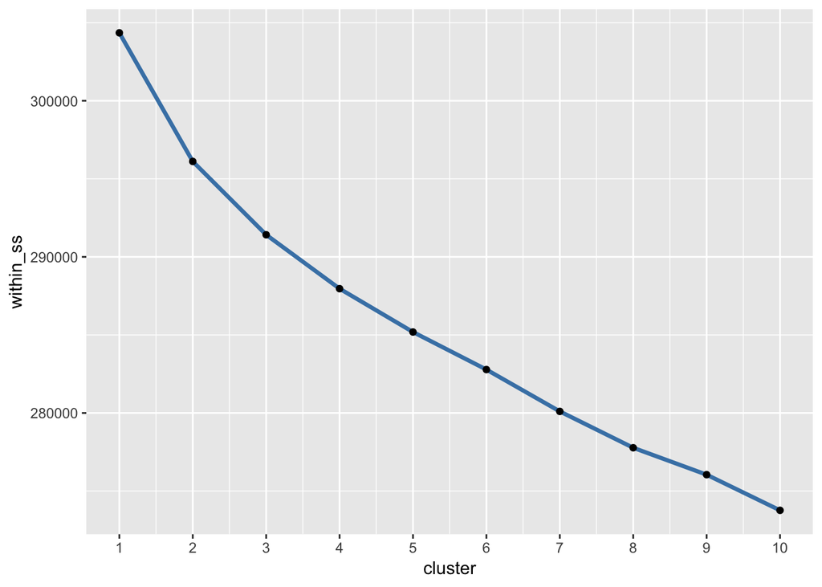

```r
within_ss = sapply(1:10,FUN = function(x) kmeans(x = trainNorm,centers = x,iter.max = 1000,nstart = 25)$tot.withinss)
ggplot(data=data.frame(cluster = 1:10,within_ss),aes(x=cluster,y=within_ss))+
  geom_line(col='steelblue',size=1.2)+
  geom_point()+
  scale_x_continuous(breaks=seq(1,10,1))
```

# Silhouette Plot:

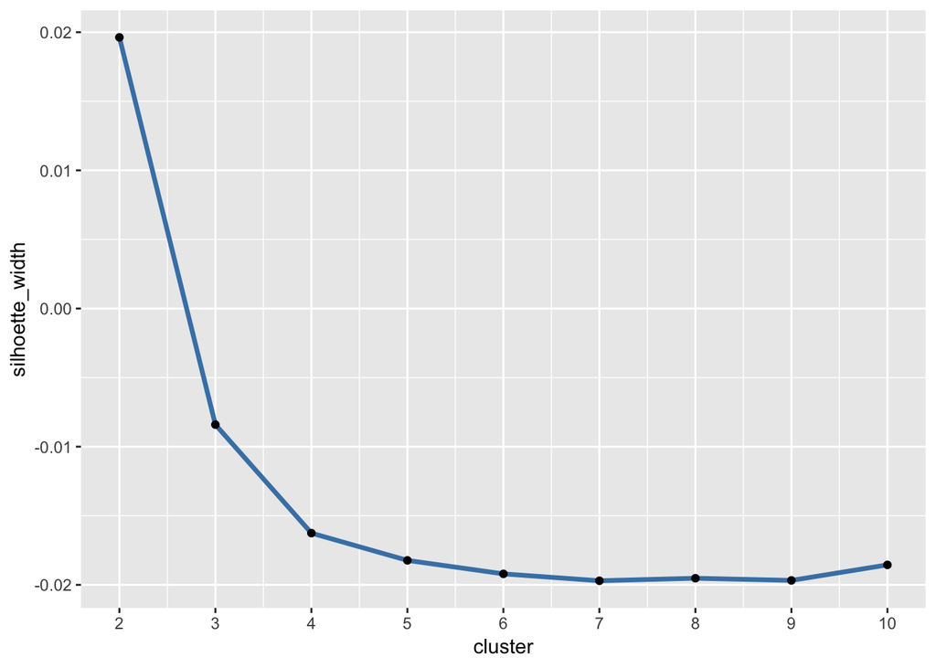

```r
silhoette_width = sapply(2:10,FUN = function(x) pam(x = trainNorm,k = x)$silinfo$avg.width)
ggplot(data=data.frame(cluster = 2:10,silhoette_width),aes(x=cluster,y=silhoette_width))+
  geom_line(col='steelblue',size=1.2)+
  geom_point()+
  scale_x_continuous(breaks=seq(2,10,1))
```

# k-means:

the elbow method and Silhoette method both support cluster of 2. We are going to go with 2 clusters.

```r
set.seed(1706)
km = kmeans(x = trainNorm,centers =2,iter.max=10000,nstart=100)
```

Applying clustering solutions from train set to validation set

```r
km_kcca = as.kcca(km,trainNorm)
clusterTrain = predict(km_kcca)
clusterValidation = predict(km_kcca,newdata=validationNorm)

#same for the actual test set
testid = testNorm$id #take out the id, save the id separately
testNorm$id = NULL
clusterTest = predict(km_kcca,newdata=testNorm)
```

Have a look at the clusterTrain and clusterValidation results below:

```r
print(table(clusterTrain))
```

```
## clusterTrain
##    1    2
## 1402  698
```

```r
print(table(clusterValidation))
```

```
## clusterValidation
##   1   2
## 594 306
```

```r
print(table(clusterTest))
```

```
## clusterTest
##    1    2
## 2947 1451
```

Split train, validation and test based on cluster membership

```r
train1 = subset(train_model,clusterTrain==1)
train2 = subset(train_model,clusterTrain==2)
validation1 = subset(validation_model,clusterValidation==1)
validation2 = subset(validation_model,clusterValidation==2)
test1 = subset(test_cluster,clusterTest==1)
test2 = subset(test_cluster,clusterTest==2)

train1label = train1$log.revenue
train2label = train2$log.revenue
validation1label = validation1$log.revenue
validation2label = validation2$log.revenue

train1$log.revenue = NULL
train2$log.revenue = NULL
validation1$log.revenue = NULL
validation2$log.revenue = NULL
```

Predict for each Cluster then Combine:

```r
#for cluster 1
xgb_train1=as.matrix(train1)
set.seed(123)
# parameter list
params = list(
  eta = 0.01,
  max_depth = 50,
  min_child_weight = 7,
  colsample_bytree = 1)
xgb.fit.final1 = xgboost(
  params = params,
  data = xgb_train1,
  label = train1label,
  nrounds = 750,
  subsample=0.55,
  objective = "reg:linear",
  print_every_n = 100)
# 0.042309 train-rmse:0.757953

xgb_scoring1=as.matrix(validation1)
pred1= predict(xgb.fit.final1,newdata=xgb_scoring1)
rmsle1 = sqrt(mean((pred1-validation1label)^2)); rmsle1
```

```
## [1] 2.036953
```

```r
#test rmsle:2.034876
```

```r
#for cluster 2
xgb_train2=as.matrix(train2)
set.seed(123)
xgb.fit.final2 = xgboost(
  params = params,
  data = xgb_train2,
  label = train2label,
  nrounds = 400,
  subsample=0.55,
  objective = "reg:linear",
  print_every_n = 100)
# train-rmse:1.276179

# for prediction
xgb_scoring2=as.matrix(validation2)
pred2= predict(xgb.fit.final2,newdata=xgb_scoring2)
rmsle2 = sqrt(mean((pred2-validation2label)^2)); rmsle2
```

```
## [1] 1.983535
```

```r
#test rmsle:1.983864
```

Now let’s combine and see what’s the overall rmsle:

```r
predOverall = c(pred1,pred2)
revenueOverall = c(validation1label,validation2label)
rmsleOverall = sqrt(mean((predOverall - revenueOverall)^2)); rmsleOverall
```

```
## [1] 2.01895
```

Let’s predict for real test now:

```r
test1id = test1$id
test1$id = NULL

test2id = test2$id
test2$id = NULL

xgb_real_test1=as.matrix(test1)
xgb_real_test2=as.matrix(test2)

pred1.test= predict(xgb.fit.final1,newdata=xgb_real_test1)
pred1.test_nolog=exp(pred1.test)-1

pred2.test= predict(xgb.fit.final2,newdata=xgb_real_test2)
pred2.test_nolog=exp(pred2.test)-1
```

Without clustering. let’s see what if we predict directly with the dummy variables dataset: Save the log.revenue label separetly and remove it from the dataset:

```r
train_modelLabel = train_model$log.revenue
validation_modellLabel = validation_model$log.revenue

train_model$log.revenue = NULL
validation_model$log.revenue=NULL
```

## XGboost Predictive Model:

We wll use the same parameter list

```r
  xgb_train=as.matrix(train_model)
  set.seed(123)
  xgb.fit.final = xgboost(
    params = params,
    data = xgb_train,
    label = train_modelLabel,
    nrounds = 750,
    subsample=0.55,
    objective = "reg:linear",
    print_every_n = 100)
  #train-rmse:0.710131

  # for prediction
  nrow(validation_model)
```

```
## [1] 900
```

```r
  xgb_scoring=as.matrix(validation_model)
  pred= predict(xgb.fit.final,newdata=xgb_scoring)
  rmsle = sqrt(mean((pred - validation_modellLabel)^2)); rmsle
```

```
## [1] 1.911839
```

```r
  #1.916718
```

Let’s predict for the test, and upload to see the test rmsle on Kaggle:

```r
  testLabel=test_cluster$id
  test_cluster$id = NULL

  xgb_real_test=as.matrix(test_cluster)
  pred.test= predict(xgb.fit.final,newdata=xgb_real_test)
  pred.test_nolog=exp(pred.test)-1

  #kaggle score: 2.20424
```

The kaggle score is 2.20424.

# Comparison

```r
paste('rmsle for model on entire data',rmsle)
```

```
## [1] "rmsle for model on entire data 1.91183886071336"
```

```r
paste('rmsle for model on clusters', rmsleOverall)
```

```
## [1] "rmsle for model on clusters 2.01894953009419"
```

Sadly, it seems like ‘cluster than predict’ does not help our model to improve at all. So for our final analysis, we decided to stick with xgboost only and focus on tune the paraters better.

Let’s now check what’s the important variables in our boosting model:

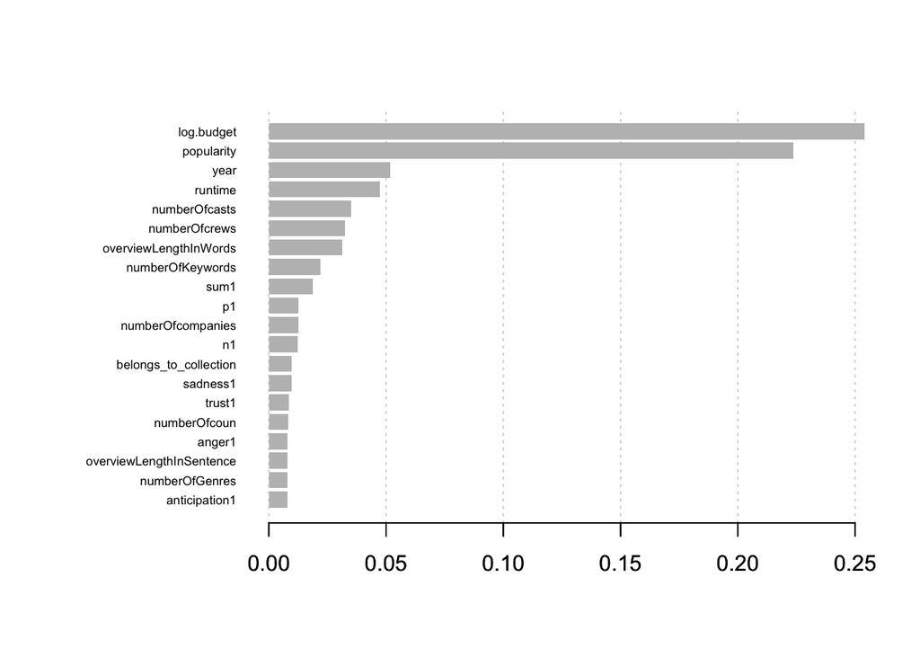

```r
importance_matrix<-xgb.importance(model =xgb.fit.final)
xgb.plot.importance(importance_matrix[1:20,])
```